# A Mixture of Flexible Multivariate Distributions

In this document, I will compute the posterior distribution for $\beta_{j}$ using the derivation in the document `next Steps’, where the prior on $\beta_{j}$ is modeled as a mixture of multivariate normals.

```r
setwd("~/Dropbox/cyclingstatistician/beta_gp_continuous/")
tuto.dir=getwd()
##' @param b.gp.hat PxR matrix of standardized effect sizes across all `R' tissue types,
##' @param se.gp.hat RxR estimated covariance matrix of standardized standard errors, corresponding to the MLE of genotype effect for a given gene-SNP pair in all tissues
##' @param t.stat PxR matrix of t statistics for each gene-snp Pair across all R tissues
##' @param U.0kl RxR prior covariance matrix for posterior.covariance matrix K and weight l
##' @param pi LxK matrix of prior weights estimated from the EM algorithm which correspond to optimal weighting of prior covariance matrix

#b.gp.hat=na.omit(read.table("16008genesnppairs_43tissues_beta.hat.std.txt",header=F,skip=1)[,-c(1,2)])
b.gp.hat=na.omit(read.table("50186simulatedbeta.hat.std.txt",header=F,skip=1)[,-c(1,2)])

#se.gp.hat=na.omit(read.table("16008genesnppairs_43tissues_sigma.hat.std.txt",header=F,skip=1)[,-c(1,2)])
se.gp.hat=na.omit(read.table("50186simulatedse.hat.std.txt",header=F,skip=1)[,-c(1,2)])

#t.stat=na.omit(read.table("16008genesnppairs_43tissues_t.stat.txt",header=F,skip=1)[,-c(1,2)])
t.stat=na.omit(read.table("50186simulatedt.hat.std.txt",header=F,skip=1)[,-c(1,2)])


#p.vals=na.omit(read.table("16008genesnppairs_43tissues_pval.txt",header=F,skip=1)[,-c(1,2)])

L = 5
R=ncol(b.gp.hat)#number of tissues
X.t=as.matrix(t.stat)
X.c=apply(X.t,2,function(x) x-mean(x)) ##Column centered matrix of t statistics
R=ncol(X.t)
M=nrow(X.t)
#colMeans(X.c)
```

Now, we need to load in the prior matrices which we will try to find the optimal combination. First we load in the `K' RxR prior covariance matrices specifying the relative importance of a particular tissue direction in each component. Now, for every prior covariance matrix $U_{k}$, we compute L`stretches’ specifying the width of this distribution. Thus for each stretch $\omega$, there will be K corresponding covariance matrices.

```r
##' @param function to return the LxK component list of prior covariance matrices
##' @param X.c a matrix of column center tstatistics
##' @param P number of PCs to keep in approximation
##' @param omega.table dataframe of stretches
##' @return return L dimensional list of K dimensional lists where each L,K contains the Lth grid component times the K covariance matrix

omega.table=read.table("~/Dropbox/cyclingstatistician/beta_gp_continuous/omega2.txt")


get.prior.covar.Ukl=function(P,L,R){
  test=list()
  for(l in 1:L){
  test[[l]]=list()
    omega=omega.table[l,]
    test[[l]][[1]]=omega*diag(1,R)# the first covariance matrix will be the 'sopped up' identity
    S=cov2cor((t(X.c)%*%X.c)/M)

test[[l]][[2]]=omega*(S)


  svd.X=svd(X.c)##perform SVD on sample centered
  #svd.X=svd(X.t)##peform SVD on unsample centered (same result for v)
  v=svd.X$v;u=svd.X$u;d=svd.X$d

  cov.pc=1/M*v[,1:P]%*%diag(d[1:P])%*%t(u[,1:P])%*%t(v[,1:P]%*%diag(d[1:P])%*%t(u[,1:P]))##Use the rank P summary representation

  test[[l]][[3]]=omega*cov2cor(cov.pc)}
return(U.0kl=test)}
```

Now that we have the prior covariance matrices, we can maximize the likelihood $L(\pi;\hat\beta_{j},se_{j})$ by computing $Pr(\hat \beta_{j} | Component k,l)$ for each gene componenet at each each gene SNP pair and then finding the optimal combination among all gene SNP pairs.

```r
##' @return Compute a likelihood using the prior covariance matrix for each gene SNP pair in the rows and componenets in the columns
##' @param b.gp.hat and se.gp.hat matrix of MLES for all J gene snp pairs
##'
##' @param U.0kl L dimensional list of K dimensional list with prior covairnace matrix for each grid weight, prior covariance pair
#install.packages("SQUAREM") note you'll need to have SQUAREM installed
library("SQUAREM")

L=5
R=5
U.0kl=get.prior.covar.Ukl(P=5,L,R)
K=length(U.0kl[[1]])
L=length(U.0kl)
#U.0kl[[L+1]]=diag(1,R) ##Add the identity matrix to the list

##J = Number of gene-snp pairs to consider
##' @return likelihood a function to return a J dimensional list of KxL vectors of likelihoods for each component
library("mvtnorm")
likelihood=function(b.gp.hat,se.gp.hat,J=nrow(b.gp.hat))
  {
  lik.i=list()
lapply(seq(1:J),function(j){
  b.mle=b.gp.hat[j,]
  V.gp.hat=diag(se.gp.hat[j,])^2

   lik=matrix(NA,nrow=K,ncol=L)
 for(l in 1:L){
for (k in 1:K){
  lik[k,l]=dmvnorm(x=b.mle, sigma=U.0kl[[l]][[k]] + V.gp.hat)
  }}
   lik.i[[j]] = as.vector(lik) ## concatenates column by column (e.g., [K=1,1],[K=2,1],[K=3,1],[2,1])


})}

##Likelihood of each component in cols, gene=snp pairs in rows##
global.lik=matrix(unlist(likelihood(b.gp.hat,se.gp.hat)),ncol=K*L,byrow=TRUE)
```

Now, to use the EM algorithm:

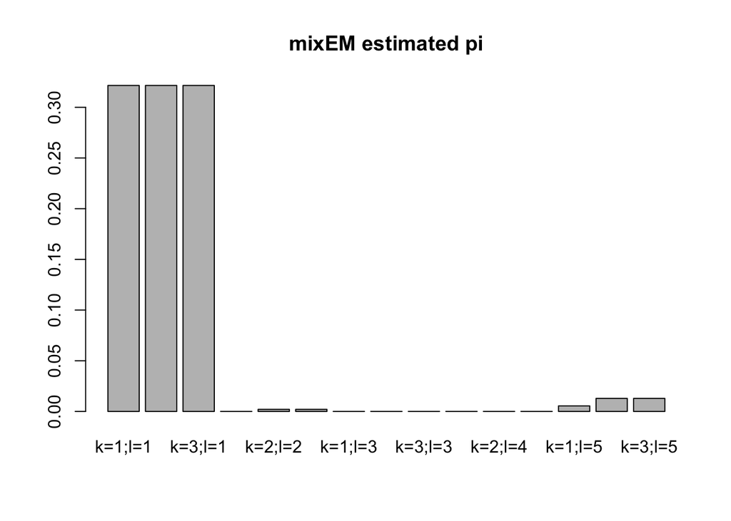

```r
#install.packages("SQUAREM")
library("SQUAREM")
pis=mixEM(matrix_lik=global.lik,prior=rep(1,K*L))
names.vec=matrix(NA,nrow=K,ncol=L)
  for(l in 1:L){
    for(k in 1:K){
      names.vec[k,l]=paste0("k=",k,";l=",l)}}

write.table((cbind(as.vector(names.vec),pis$pihat)),quote=FALSE,file="piklhat.txt")
pi.hat=read.table(file="piklhat.txt")
barplot(pis$pihat,names=as.vector(names.vec),main="mixEM estimated pi")
```

I compare with naiive iteration, which simply weights the relative likelihood across individuals.

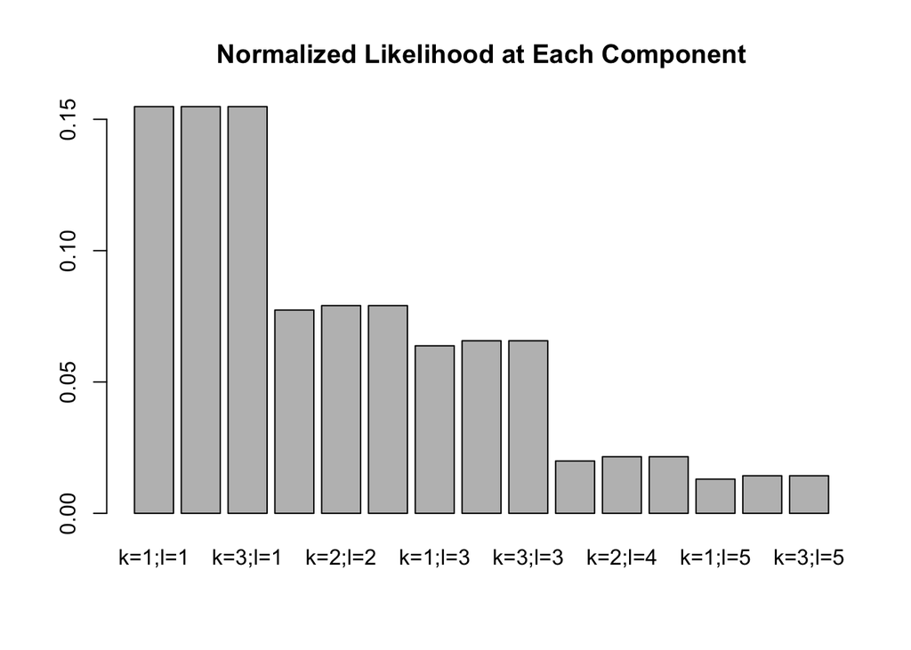

```r
##' @param global.lik Computes the likelihood matrices for each componenet for each of j gene snp pairs
##' @return global.sum Sums the likelihood for each component across j gene snp pairs
##' @return global.norm Sums the likelihood for all components across all j pairs


library("mvtnorm")

updated.weights=function(b.gp.hat,se.gp.hat,global.lik){
    global.sums=as.matrix(colSums(global.lik))#relative importance of each componenet across all gene-snp pairs
  global.norm=sum(global.sums)
return(updated.weights=global.sums/global.norm)}

names.vec=matrix(NA,nrow=K,ncol=L)
  for(l in 1:L){
    for(k in 1:K){
      names.vec[k,l]=paste0("k=",k,";l=",l)}}

x=updated.weights(b.gp.hat,se.gp.hat,global.lik)
barplot(as.vector(x),names=as.vector(names.vec),main="Normalized Likelihood at Each Component")
```

Here, I’ve plotted the relative importance of each component after one iteration with a uniform prior weight on each $\pi$.

Recall:

$L(\beta_{j};k,l) = Pr(\hat{b}_{j} | k,l)$ $=Pr(\hat{b}_{j}; 0, \omega^{2}_{l} U_{k} + \hat {V})$

$w_{jkl} = \frac{\pi_{k,l} L(\beta_{j};k,l)}{\sum_{k,l} \pi_{k,l} L(\beta_{j};k,l)}$

We can then update our estimate of $\pi_{k,l}$

$\pi_{kl}^{i+1} = \frac{\sum_{j} w_{jkl}}{\sum_{j,k,l} w_{jkl}}$

## Posterior computation

Now that we have the hierarchical weights $\pi_{k,l}$, we can compute the posterior distribution for each component.

For a given prior covariance matrix, compute posterior covariance and posterior mean. Here, let U.0k.l represent a specific matrix in U.0kl (.e.g, $U.0kl[[l]][[k]]$)

```r
##' @param U.0k.l let U.0k.l represent a specific matrix in U.0kl (.e.g, U.0kl[[l]][[k]])
##' @return post.b.gpkl.cov ## returns an R*R posterior covariance matrix for jth gene snp pair
##' @return post.b.gpkl.mean return a 1 * R vector of posterior means for a given prior covariance matrix

post.b.gpkl.cov <- function(V.gp.hat.inv, U.0k.l){
        U.gp1kl <- U.0k.l %*% solve(V.gp.hat.inv %*% U.0k.l + diag(nrow(U.0k.l)))
            return(U.gp1kl)
    }

post.b.gpkl.mean <- function(b.mle, V.gp.hat.inv, U.gp1kl){
        mu.gp1kl <- U.gp1kl %*% V.gp.hat.inv %*% b.mle
            return(mu.gp1kl)
    }
```

We also need to compute the “posterior weights” corresponding to each prior covariance matrix, which is simply the likelihood evaluated at that componenet times the prior weigth, $pi_{k,l}$ normalized by the marginal likelihood over all components.

$p(k=1,l=1|D)=$ $\frac{p(D|k=1,l=1)*p(k=1,l=1)}{p(D)}$

```r
##' @param pi.hat = matrix of prior weights
##' @return a vector of posterior weights
pis=pi.hat[,2]
post.weight.func=function(pis,U.0kl,V.gp.hat,b.mle){
post.weight.num = matrix(NA,nrow=K,ncol=L)
for(k in 1:K){
for(l in 1:L){
  wts=matrix(pis,nrow=K,ncol=L)
  pi=wts[k,l]
  post.weight.num[k,l]=pi*dmvnorm(x=b.mle, sigma=U.0kl[[l]][[k]] + V.gp.hat)}
}
post.weight=post.weight.num/sum(post.weight.num)
return(as.vector(post.weight))}
```

```r
##' @param U.0kl = l dimensional list of k dimensional list of prior covariance matrices
##' @returm all.means, a J dimensional list of k dimensional lists of L dimensional list of 1xR vectors of posterior means
##' @returm all.covs, a J dimensional list of k dimensional lists of L dimensional list of RxR posterior covariances
##' @returm post.weight.matrix a J x (K*L) matrix of posterior weights coresponding to p(K,L|D) for each gene-snp Pair


all.covs=list()
all.means=list()
   all.up=list()
      all.low=list()
     all.null=list()
J=dim(b.gp.hat)[1]
#lapply(seq(1:J),function(j){
  for(j in 1:J){
    b.mle=as.vector(t(b.gp.hat[j,]))##turn i into a 43 x 1 vector
    V.gp.hat=diag(se.gp.hat[j,])^2
    all.covs[[j]]=list()
    all.means[[j]]=list()
     all.up[[j]]=list()
      all.low[[j]]=list()
     all.null[[j]]=list()
    #temp.mean=matrix(NA,nrow=)

            V.gp.hat.inv <- solve(V.gp.hat)
          for(k in 1:K){
            all.covs[[j]][[k]]=list()
            all.means[[j]][[k]]=list()
            all.up[[j]][[k]]=list()
            all.low[[j]][[k]]=list()
            all.null[[j]][[k]]=list()

            for (l in 1:L){
                  all.means[[j]][[k]][[l]]=list()
                  all.covs[[j]][[k]][[l]]=list()
                   all.up[[j]][[k]][[l]]=list()
                  all.low[[j]][[k]][[l]]=list()
                   all.null[[j]][[k]][[l]]=list()
                  U.gp1kl <- post.b.gpkl.cov(V.gp.hat.inv, U.0kl[[l]][[k]]) ## returns an R*R posterior covariance matrix for jth gene snp pair
                  mu.gp1kl <- post.b.gpkl.mean(b.mle, V.gp.hat.inv, U.gp1kl) ##return a 1 * R vector of posterior means for a given prior covariance matrix
                  all.means[[j]][[k]][[l]]=mu.gp1kl
                  all.covs[[j]][[k]][[l]]=U.gp1kl
                  all.up[[j]][[k]][[l]]=rep(0,R)
                  all.low[[j]][[k]][[l]]=rep(0,R)
                  all.null[[j]][[k]][[l]]=rep(0,R)
                  all.sds=sqrt(diag(U.gp1kl))
                  for(r in 1:R){
                    if(all.sds[r]==0){
                    all.up[[j]][[k]][[l]][r]=0#need to figure out how to make the list have individual entries
                  all.low[[j]][[k]][[l]][r]=0
                   all.null[[j]][[k]][[l]][r]=1}
                      else{
                   all.up[[j]][[k]][[l]][r]=pnorm(0,mean=mu.gp1kl[r],sd=sqrt(diag(U.gp1kl))[r],lower.tail=F)
                  all.low[[j]][[k]][[l]][r]=pnorm(0,mean=mu.gp1kl[r],sd=sqrt(diag(U.gp1kl))[r],lower.tail=T)
                   all.null[[j]][[k]][[l]][r]=0}

                  }
           }
    }
    }
```

Now, for each of the $J$ gene-snp pairs we generate a matrix of posterior weight matrix. Remember, this will not be tissue specific information, so we need to do it only once and can store in an Jx(K*L) matrix

```r
library("mvtnorm")
post.weight.matrix=matrix(NA,nrow=J,ncol=L*K)
J=dim(b.gp.hat)[1]


for(j in 1:J){
    b.mle=as.vector(t(b.gp.hat[j,]))##turn i into a 43 x 1 vector
    V.gp.hat=diag(se.gp.hat[j,])^2
    pis=pi.hat[,2]
    U.0kl=U.0kl
    post.weight.matrix[j,]=as.vector(post.weight.func(pis,U.0kl,V.gp.hat,b.mle))
}
```

```r
#par(mfrow=c(3,3))

L=5
ls.mat=read.table("lfsr.50186.txt")
apply(ls.mat,2,which.min)
```

```
##    V1    V2    V3    V4    V5
##  5166  5166 17635   548   548
```

```r
apply(ls.mat,2,which.max)
```

```
##    V1    V2    V3    V4    V5
## 18530 18530 22810 18597 33419
```

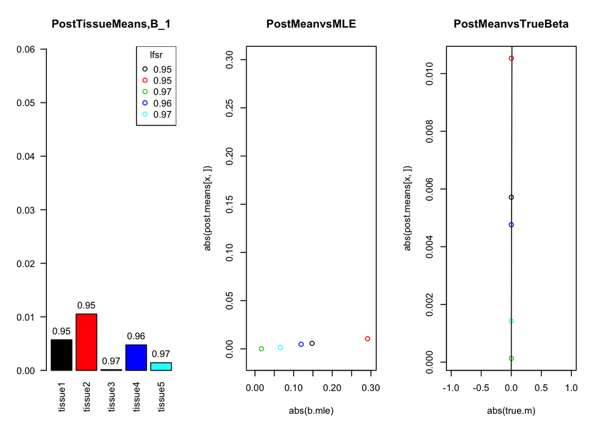

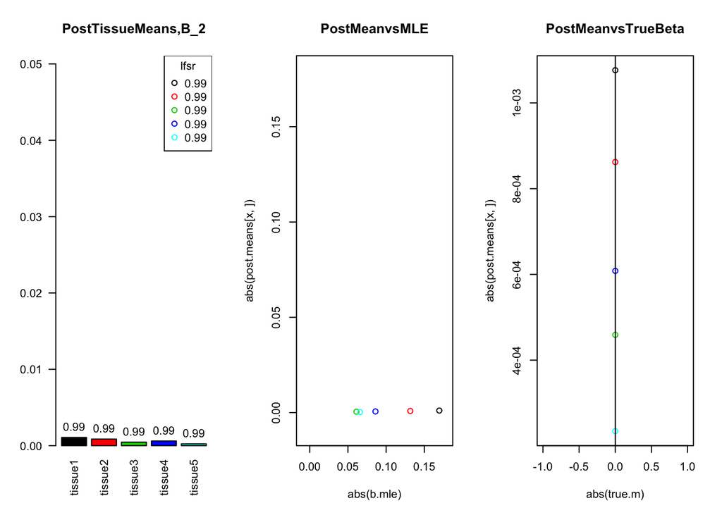

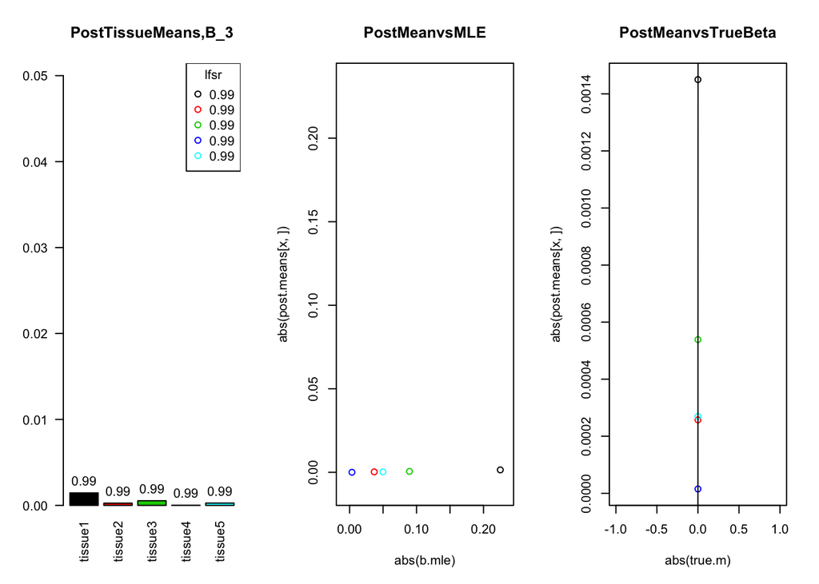

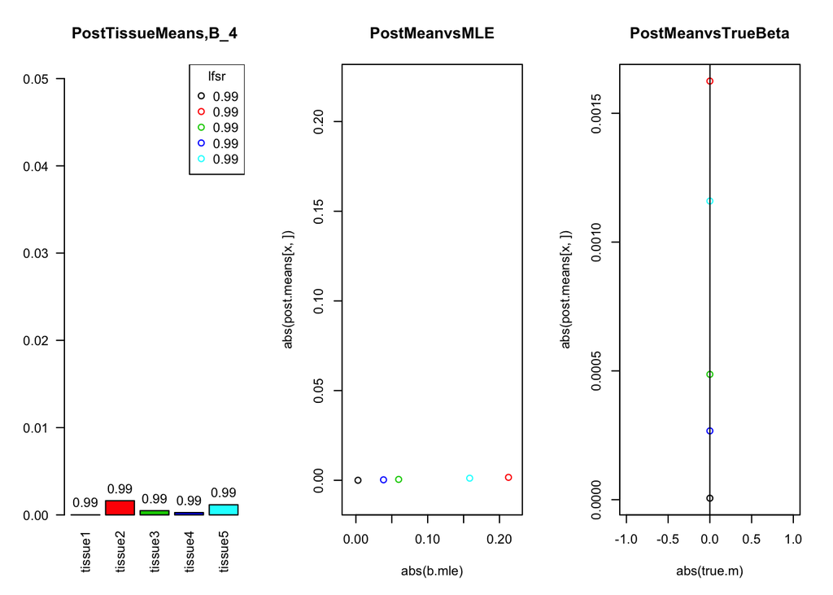

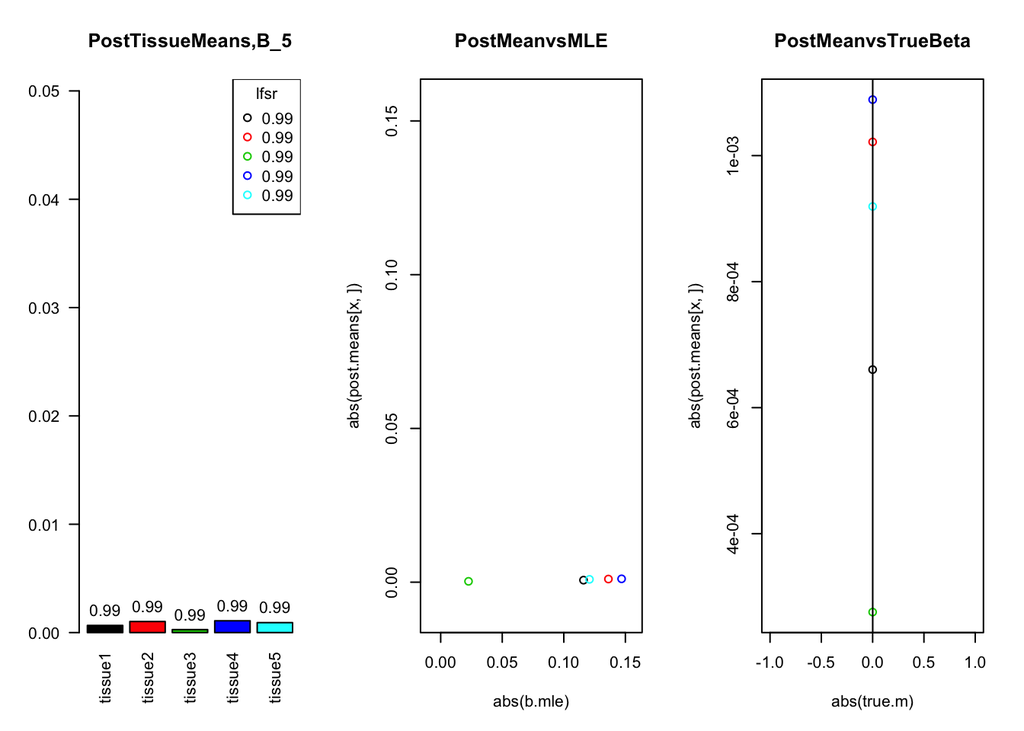

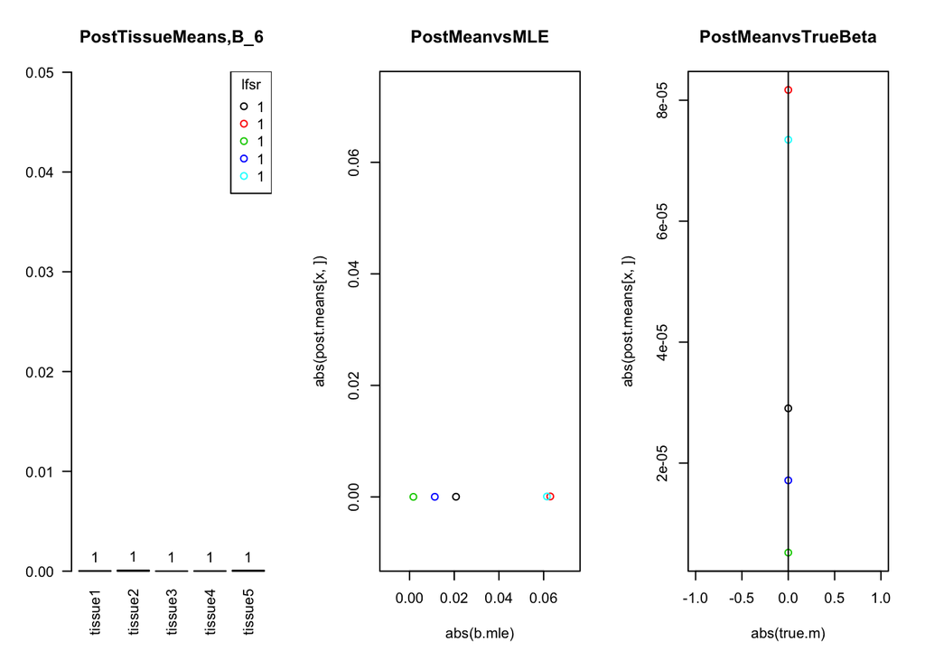

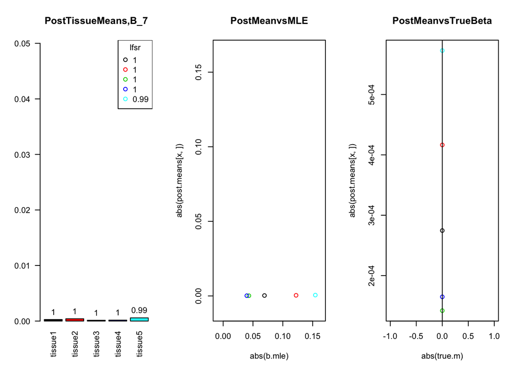

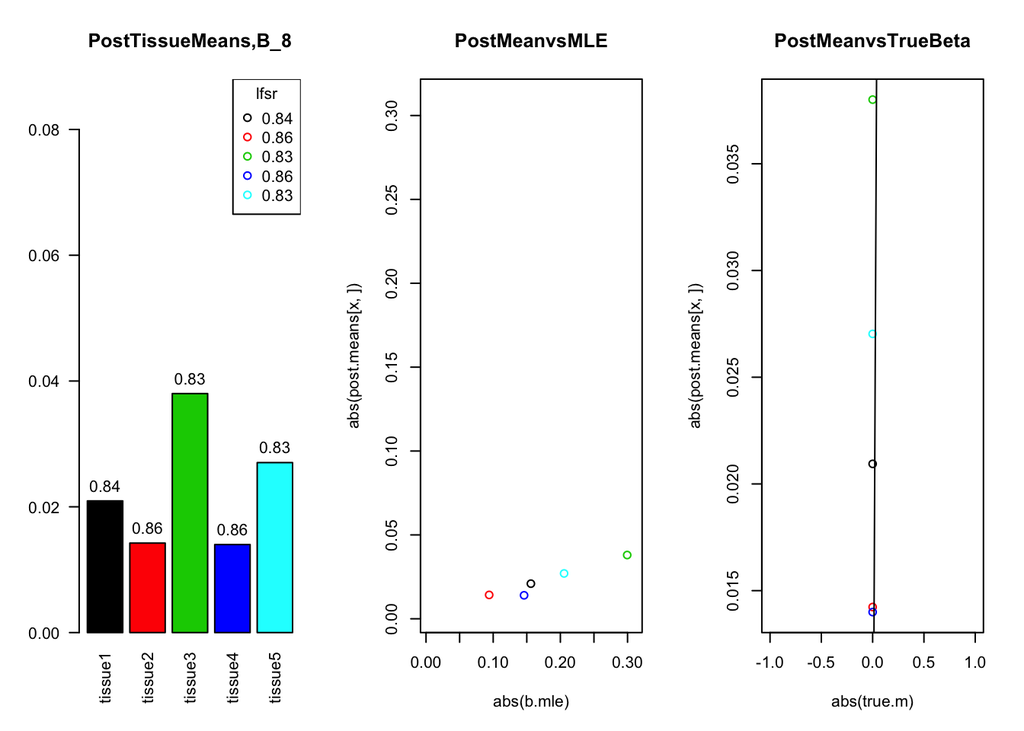

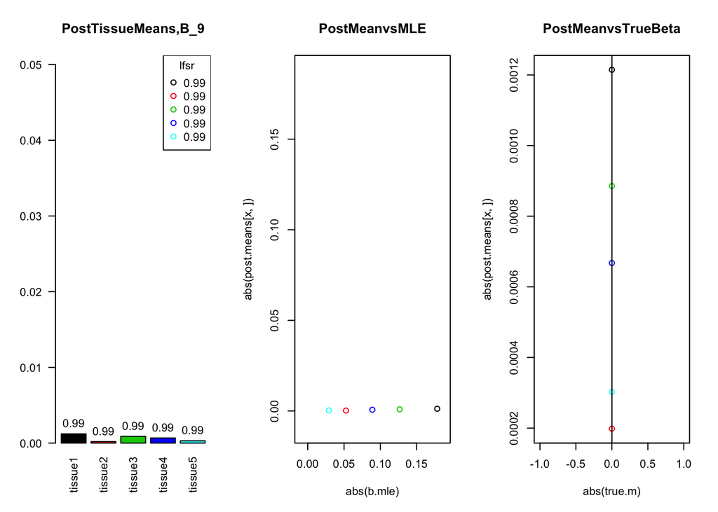

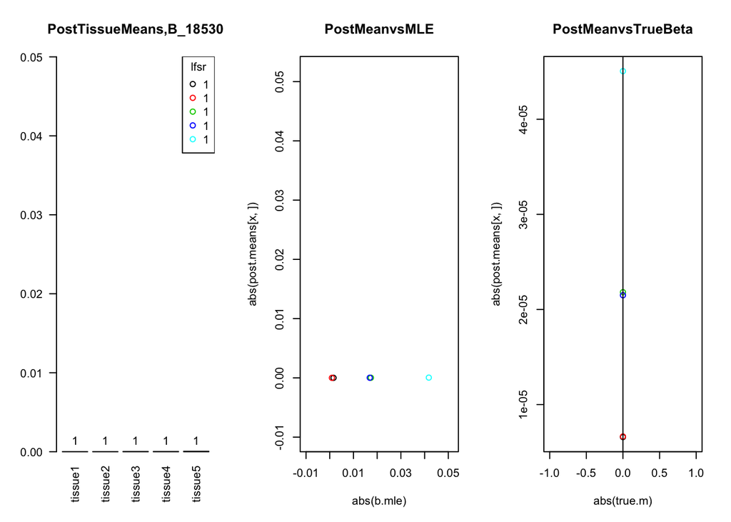

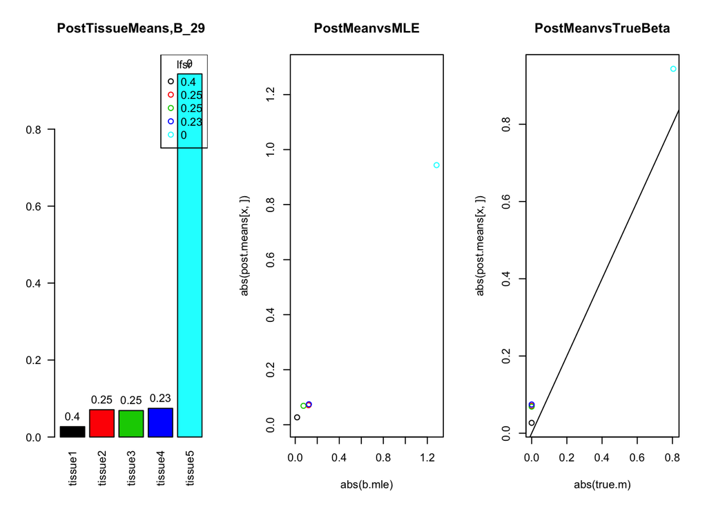

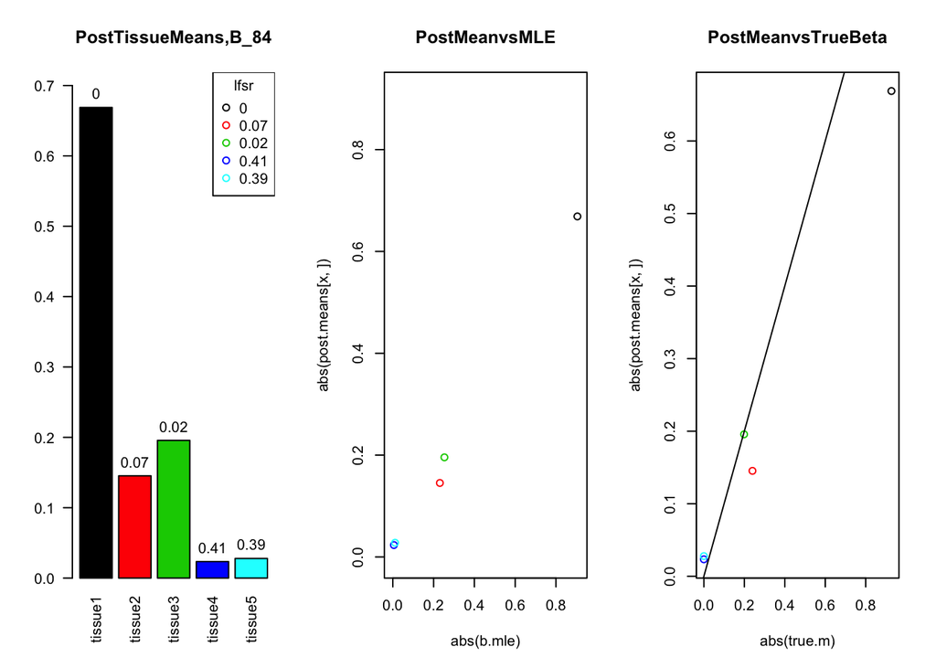

[8 more figures not shown]

```r
false=which(truth$config==0)
real=which(truth$config!=0)
snps=c(false[1:9],18530,real[1:8],5166,548)
J=length(snps)


post.means=matrix(NA,nrow=J,ncol=R)
post.ups=matrix(NA,nrow=J,ncol=R)
post.lows=matrix(NA,nrow=J,ncol=R)
post.null=matrix(NA,nrow=J,ncol=R)
lfsr.mat=matrix(NA,nrow=J,ncol=R)

for(x in 1:length(snps)){
j=snps[x]
#if(plot=FALSE)
  #{J=nrow(b.gp.hat)
#for(x in 1:nrow(b.gp.hat)){
#j=x



mean.list=all.means[[j]]
upper.list=all.up[[j]]
lower.list=all.low[[j]]
null.list=all.null[[j]]

post.weights=post.weight.matrix[j,]
post.weight.mat=matrix(post.weights,nrow=K,ncol=L)
post.weight.mat[is.na(post.weight.mat)] <- 0
truth[j,]
temp=NULL
temp.up=NULL
temp.low=NULL
temp.null=NULL


for(k in 1:K){
for(l in 1:L){
temp=rbind(as.vector(post.weight.mat[k,l]*mean.list[[k]][[l]]),temp)##creates a 6x43 matrix of posterior means, but in [k=3,l=2][k=3,l=1][k=2,l=2][k=2,l=1] etc. (which is ok because we simply sum)

up.row=as.vector(upper.list[[k]][[l]]*post.weight.mat[k,l])
up.row=t(as.matrix(up.row))
temp.up=rbind(temp.up,up.row)
temp.low=rbind(as.vector(post.weight.mat[k,l]*as.matrix(lower.list[[k]][[l]])),temp.low)
temp.null=rbind(as.vector(post.weight.mat[k,l]*as.matrix(null.list[[k]][[l]])),temp.null)

}
}
post.means[x,]=t(colSums(temp))
post.ups[x,]=t(colSums(temp.up))
post.lows[x,]=t(colSums(temp.low))
post.null[x,]=t(colSums(temp.null))
lfsr.mat[x,]=as.matrix(apply(rbind(post.ups[x,],post.lows[x,]),2,function(x){1-max(x)}))

lfsr=lfsr.mat[x,]

#if(plot=TRUE){
#pdf(paste0("PostTissueMeans,B_",j))
par(mfrow=c(1,3))
#barplot(post.means[j,],main=paste0("PostTissueMeans,B_",j),col=c(1:43),las=2,names=names[-44])
b=barplot(abs(post.means[x,]),main=paste0("PostTissueMeans,B_",j),col=c(1:R),las=2,names=names,beside=TRUE,ylim=c(0,max(abs(post.means[x,]))+0.05))
text(b, abs(post.means[x,]), labels=round(lfsr,2), pos=3, offset=.5)
legend("topright",legend=round(lfsr,2),col=c(1:R),pch=1,title="lfsr")
b.mle=t(b.gp.hat[j,])
a.m=abs(b.mle)
a.p=abs(post.means[x,])
low=min(a.m-0.01,a.p-0.01)
high=max(a.m+0.01,a.p+0.01)
plot(abs(b.mle),abs(post.means[x,]),main="PostMeanvsMLE",xlim=c(low,high),ylim=c(low,high),col=c(1:R))

true.m=as.numeric(truth[j,c(4:8)])
plot(abs(true.m),abs(post.means[x,]),col=c(1:R),main="PostMeanvsTrueBeta")

abline(0,1)##concern because the order of magnitude diff, but prior weight heavy on (U.0kl[[2]][[3]]) which has very small avg. variance
#dev.off()

}
```

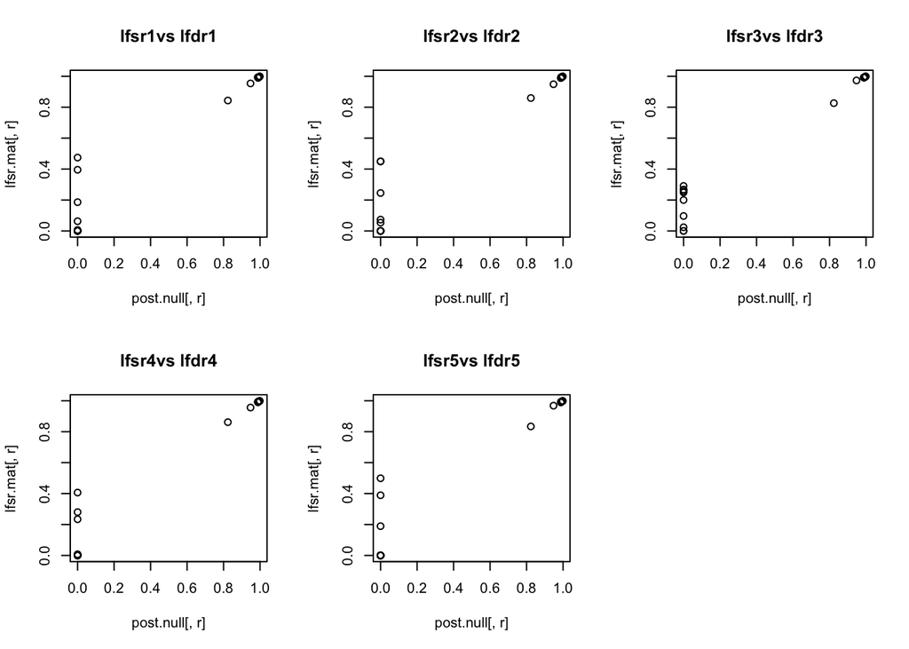

```r
# pdf("plotalllfsr.pdf")
# par(mfrow=c(5,5))
# for(r in seq(1:R)){
#   for (p in seq(1:R)){
#     plot(lfsr.mat[,p],lfsr.mat[,r])
#     }
#   }
# dev.off()
#
# write.table(post.null,"lfdr.txt")

par(mfrow=c(2,3))
for( r in seq(1:R)){
  plot(post.null[,r],lfsr.mat[,r],main=paste0("lfsr",r,"vs lfdr", r))
}
```

In order to compute the factors, we perform the following analysis.

```r
sfa -gen ./centered.t.stats.txt -g 6904 -n 43 -o tri -k 18 (here, we want each row to be maximally loaded on 1 factor, and each factor to correspond to a specific subset of tissues)
sfa -gen ./50186centered.t.stats.txt -g 50186 -n 5 -o tritut -k 20 (here, we want each row to be maximally loaded on 1 factor, and each factor to correspond to a specific subset of tissues)
```

Then, I will use $K=18$ factor representations of the covariance matrix of $X^{t}X$.

```r
# library("mvtnorm")
# lambda=as.matrix(read.table("tri_lambda.out"))
# factor=as.matrix(read.table("tri_F.out"))
# #P=25
# P=5
# get.prior.covar.Ukl=function(P,L,R,F=18){
#   test=list()
#   for(l in 1:L){
#   test[[l]]=list()
#     omega=omega.table[l,]
#     test[[l]][[1]]=omega*diag(1,R)# the first covariance matrix will be the 'sopped up' identity
#     test[[l]][[2]]=omega*cov2cor((t(X.c)%*%X.c)/M)
#
#
#   svd.X=svd(X.c)##perform SVD on sample centered
#   #svd.X=svd(X.t)##peform SCD on unsample centered (same result for v)
#   v=svd.X$v;u=svd.X$u;d=svd.X$d
#
#     cov.pc=1/M*v[,1:P]%*%diag(d[1:P])%*%t(u[,1:P])%*%t(v[,1:P]%*%diag(d[1:P])%*%t(u[,1:P]))##Use the rank P summary representation, also has shrinkage implications
#
#
#   #cov.pc=1/M*v[,1:P]%*%diag(d[1:P])%*%t(v[,1:P])##Use the rank P summary representation
#
#   test[[l]][[3]]=omega*cov2cor(cov.pc)
#   for(f in 1:F){
#     load=as.matrix(lambda[,f])
#     fact=t(as.matrix(factor[f,]))
#     rank.prox=load%*%fact
#     a=cov2cor(1/M*(t(rank.prox)%*% rank.prox))
#     a[is.nan(a)] = 0
#     test[[l]][[f+3]]=omega*a
#     }
#      full.rank=lambda%*%factor
#   b=cov2cor(1/M*(t(full.rank)%*%full.rank))
#   b[is.nan(b)]=0
#   test[[l]][[F+4]]=omega*b}##Note that this is NOT equivalent to the original covariance matrix because  the maximum number of cactors is limited to 10
#
# return(U.0kl=test)}
#
# U.0kl=get.prior.covar.Ukl(P=25,L=2,R=43,F=18)
# K=length(U.0kl[[1]])
# L=length(U.0kl)
# ##Now, compute the additional likielihoods
# global.lik=matrix(unlist(likelihood(b.gp.hat,se.gp.hat)),ncol=K*L,byrow=TRUE)
# pis2=mixEM(matrix_lik=global.lik,prior=rep(1,K*L))
# names.vec=matrix(NA,nrow=K,ncol=L)
#   for(l in 1:L){
#     for(k in 1:K){
#       names.vec[k,l]=paste0("k=",k,";l=",l)}}
#
# #write.table((cbind(as.vector(names.vec),pis$pihat)),quote=FALSE,file="piklhat.txt")
# #pi.hat=read.table(file="piklhat.txt")
# par(mfrow=c(2,1))
# barplot(pis2$pihat,main="mixEM estimated pi",names=names.vec,las=2,col=c(1:14))
#
#
# x=updated.weights(b.gp.hat,se.gp.hat,global.lik)
# barplot(as.vector(x),main="naiiveWeights estimated pi",names=names.vec,las=2,col=c(1:14))
```